# Midterm Part 1

### Topic 1: Using The Right Color Scale

#### Introduction

In this part we are showing how the importance of choosing the right colour scale for your data. The data used in this section is the same default data set used above

#### The Code

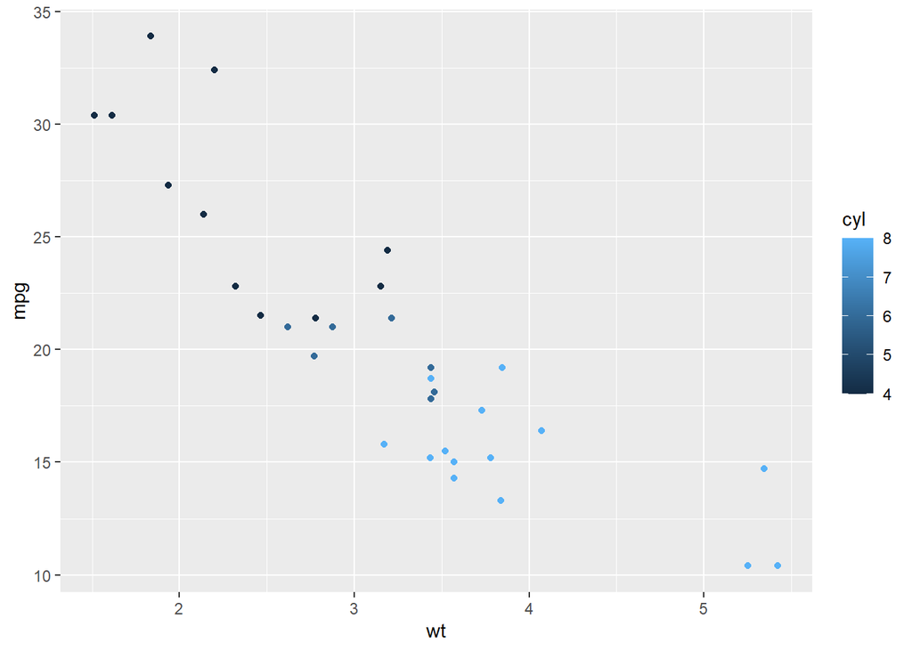

```r
ggplot(data = mtcars, aes(x = wt,
                          y = mpg)) +
  geom_point(aes(colour = cyl))
```

The graph is a perfect example for how to use color scale. By default R chooses a continuous color scheme for the amount of cylinders while it in fact is discrete. This can be changed using a different color scheme

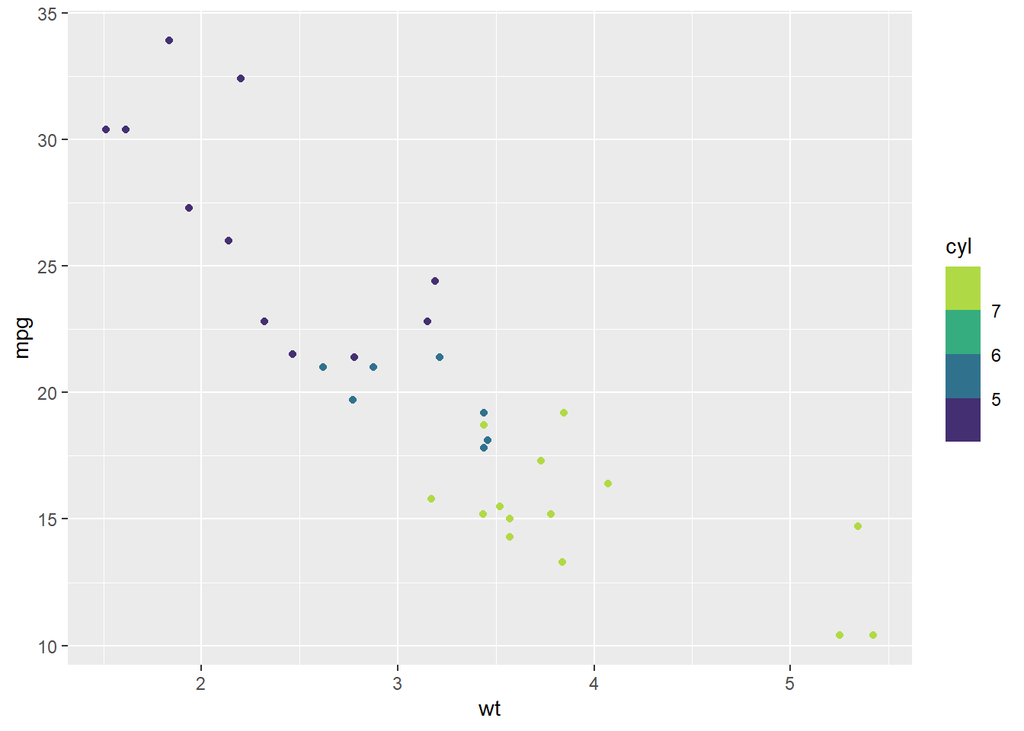

```r
ggplot(data = mtcars, aes(x = wt,
                          y = mpg)) +
  geom_point(aes(colour = cyl)) +
  scale_color_viridis_b()
```

### Topic 2: Scaling Graphs

#### Introduction:

Altering the scale of a graph is sometimes useful in order to show certain patterns but sometimes it can make the user draw wrongful conclusions. For this section we’re using nfl data to make comparisons between teams’ total points.

```r
library(here)
standings_df <- read_csv(here("data/standings.csv"))
```

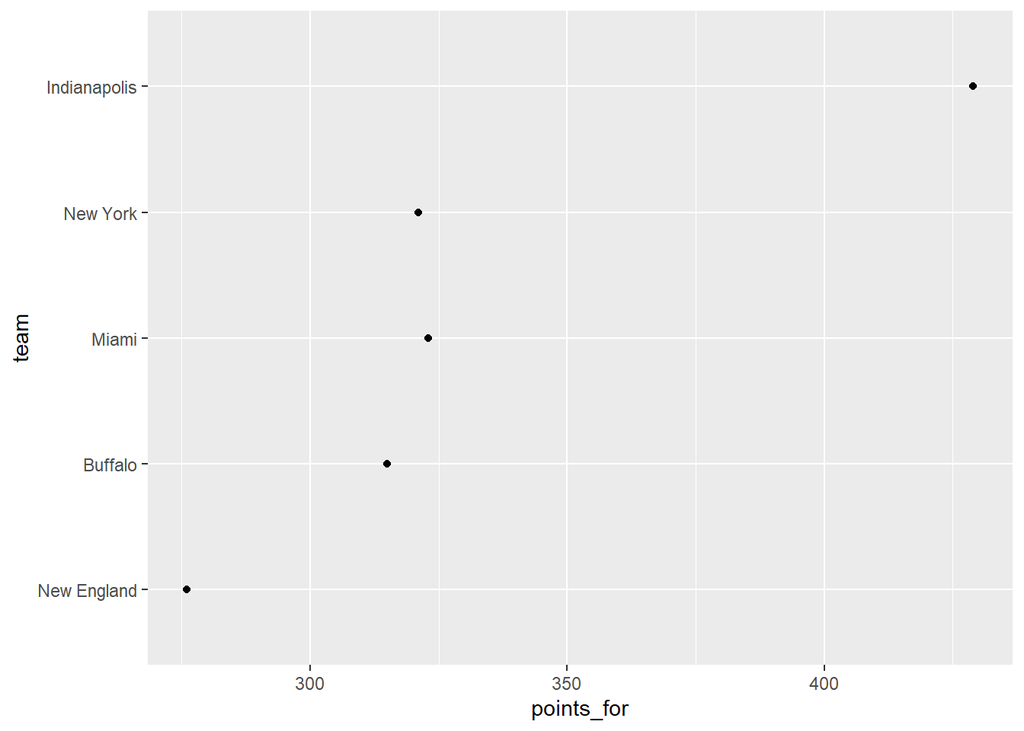

```r
two_df <- standings_df %>%
  filter(year == 2000) %>%
  mutate(team = fct_reorder(team, points_for)) %>%
  slice(1:5)

ggplot(data = two_df, aes(y = points_for,
                          x = team)) +
  geom_point() +
  coord_flip()
```

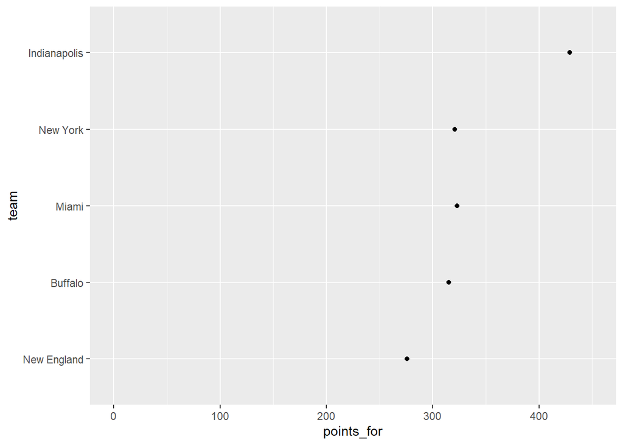

```r
ggplot(data = two_df, aes(y = points_for,
                          x = team)) +
  geom_point() +
  ylim(0, 450) +
  coord_flip()
```

Here we can see that the difference isn’t as big as the first graph showed.